# Atividade 4

Isabella

04/10/2021

## Informações gerais

A atividade 4 da disciplina foi a elaboração dessa página, construída com os passos realizados na atividade 3.

A atividade 3 foi sobre a aquisição de dados em bases abertas, utilizando o [GBIF](https://www.gbif.org/) e o [OBIS](https://obis.org/). No meu caso, escolhi a espécie *Eretmochelys imbricata* para o exercício prático.

Na primeira etapa foram obtidos e trabalhos dados no GBIF. Na segunda etapa foram obtidos e trabalhados dados do OBIS. A terceira etapa foi a junção dos dados resultantes das duas etapas anteriores. Na quarta etapa os dados foram utilizados funções e pacotes para retirar dados restantes e chegar a um gráfico final de ocorrência.

## GBIF

Abrir os pacotes necessários

```r
library(rgbif)
library(tidyverse)
```

Baixar as ocorrências

Checar número de linhas, número de colunas e nome das colunas

```r
dim(eret_gbif$data)
```

```
## [1] 500 145
```

```r
eret_gbif$data %>% names
```

```
##   [1] "key"
##   [2] "scientificName"
##   [3] "decimalLatitude"
##   [4] "decimalLongitude"
##   [5] "issues"
##   [6] "datasetKey"
##   [7] "publishingOrgKey"
##   [8] "installationKey"
##   [9] "publishingCountry"
##  [10] "protocol"
##  [11] "lastCrawled"
##  [12] "lastParsed"
##  [13] "crawlId"
##  [14] "hostingOrganizationKey"
##  [15] "basisOfRecord"
```

[output cut: 130 more lines]

Checar erros

```r
issues_gbif <- eret_gbif$data$issues %>%
  unique()
gbif_issues() %>%
  data.frame() %>%
  filter(code %in% issues_gbif)
```

```
##      code                              issue
## 1  cdreps COORDINATE_REPROJECTION_SUSPICIOUS
## 2 cdround                 COORDINATE_ROUNDED
## 3    cudc   COUNTRY_DERIVED_FROM_COORDINATES
##                                                                                                                                     description
## 1 Indicates successful coordinate reprojection according to provided datum, but which results in a datum shift larger than 0.1 decimal degrees.
## 2                                                                                       Original coordinate modified by rounding to 5 decimals.
## 3                                                     The interpreted country is based on the coordinates, not the verbatim string information.
##         type
## 1 occurrence
## 2 occurrence
## 3 occurrence
```

Selecionar e investigar variáveis

```r
eret_gbif1 <- eret_gbif$data %>%
  dplyr::select(scientificName, acceptedScientificName, decimalLatitude, decimalLongitude,
                issues, waterBody, basisOfRecord, occurrenceStatus, rightsHolder,
                datasetName, recordedBy, depth, locality, habitat) %>%
  distinct()
lapply(eret_gbif1, unique)
```

```
## $scientificName
## [1] "Eretmochelys imbricata (Linnaeus, 1766)"
## [2] "Eretmochelys imbricata bissa (Rüppell, 1835)"
##
## $acceptedScientificName
## [1] "Eretmochelys imbricata (Linnaeus, 1766)"
## [2] "Eretmochelys imbricata bissa (Rüppell, 1835)"
##
## $decimalLatitude
##   [1]  20.772141  23.372246  13.755838  13.654270 -23.987742  13.685593
##   [7] -12.500000 -11.500000 -20.553725  13.626754 -31.512355 -33.821944
##  [13] -34.330249  -4.610704  19.349698  13.620643  13.625166  -2.211328
##  [19]  28.558487  -4.603543 -27.462245   5.011638  16.150224   1.250887
##  [25]  26.275155  21.675205  18.513453   7.665419  -0.993244   1.233597
##  [31]   1.300815   5.675622  -8.305534 -10.546736 -21.981193   3.673731
```

[output cut: 714 more lines]

Como não foi preciso retirar dados encontrados no passo “Checar erros”, nem no passo “Selecionar e investigar variáveis”, segui para a criação do mapa.

```r
eret_gbif_ok <- eret_gbif1
```

Carregar pacotes para o mapa e o mapa mundi

```r
library(ggmap)
```

```r
library(maps)
library(mapdata)
world <- map_data('world')
```

Ver os pontos

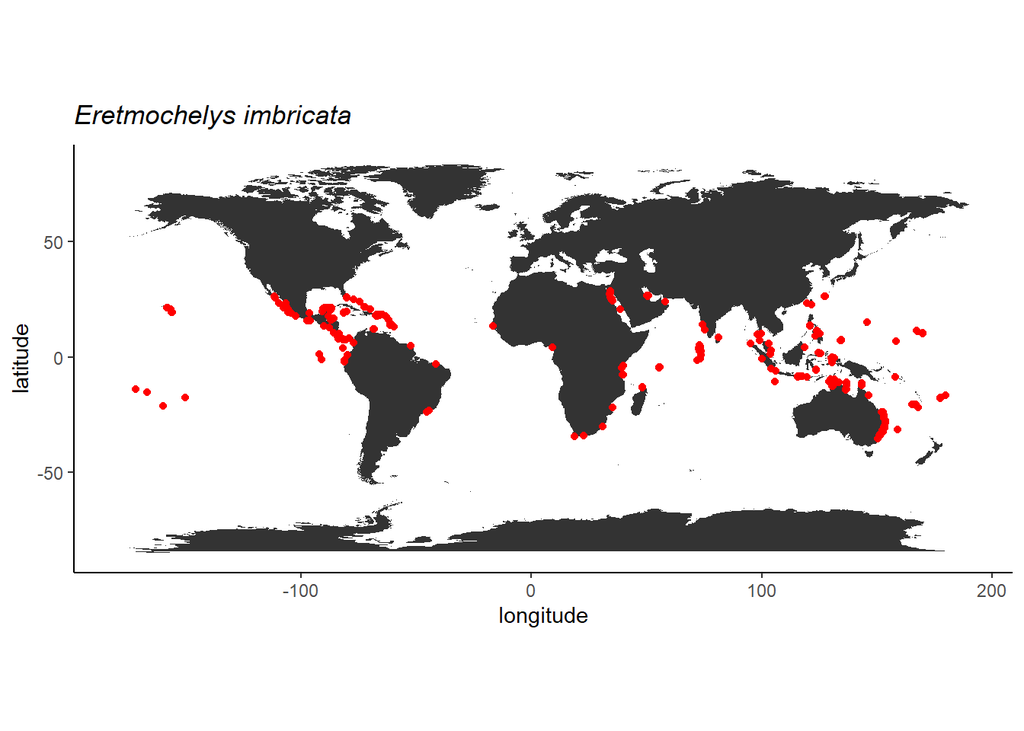

```r
ggplot() +
  geom_polygon(data = world, aes(x = long, y = lat, group = group)) +
  coord_fixed() +
  theme_classic() +
  geom_point(data = eret_gbif_ok, aes(x = decimalLongitude, y = decimalLatitude), color = "red") +
  labs(x = "longitude", y = "latitude", title = expression(italic("Eretmochelys imbricata")))
```

## OBIS

Abrir o pacote necessário

```r
library(robis)
```

Baixar as ocorrências

```
## Retrieved 5000 records of approximately 12191 (41%) Retrieved 10000 records of
## approximately 12191 (82%) Retrieved 12191 records of approximately 12191 (100%)
```

Checar nome das colunas

```r
names(eret_obis)
```

```
##   [1] "country"
##   [2] "date_year"
##   [3] "scientificNameID"
##   [4] "scientificName"
##   [5] "superfamilyid"
##   [6] "individualCount"
##   [7] "dropped"
##   [8] "aphiaID"
##   [9] "decimalLatitude"
##  [10] "phylumid"
##  [11] "familyid"
##  [12] "catalogNumber"
##  [13] "occurrenceStatus"
##  [14] "basisOfRecord"
##  [15] "superclass"
```

[output cut: 138 more lines]

Selecionar colunas e registros únicos

```r
eret_obis1 <- eret_obis %>%
  dplyr::select(scientificName, decimalLatitude, decimalLongitude, bathymetry,
                flags, waterBody, basisOfRecord, occurrenceStatus, rightsHolder,
                datasetName, recordedBy, depth, locality, habitat) %>%
  distinct()
```

Checar problemas reportados (flags)

```r
eret_obis1 %>%
  distinct(flags)
```

```
## # A tibble: 12 x 1
##    flags
##    <chr>
##  1 <NA>
##  2 no_depth
##  3 no_depth,on_land
##  4 on_land
##  5 on_land,no_depth
##  6 on_land,depth_exceeds_bath
##  7 no_depth,marine_unsure
##  8 marine_unsure,no_depth
##  9 depth_exceeds_bath,on_land
## 10 marine_unsure,no_depth,on_land
## 11 depth_exceeds_bath
## 12 no_depth,on_land,marine_unsure
```

```r
eret_obis1 %>%
  filter(!flags %in% c("on_land,no_depth","no_depth,on_land", "on_land", "on_land,depth_exceeds_bath", "depth_exceeds_bath,on_land"),
         !is.na(datasetName)) %>%
  lapply(., unique)
```

```
## $scientificName
## [1] "Eretmochelys imbricata"
##
## $decimalLatitude
##    [1]  23.500000  21.500000  -1.500000  14.500000  12.504000  14.820000
##    [7]  18.645000  -0.500000   9.500000  25.937867  18.130182  13.575000
##   [13]  14.774000  18.993780  10.910000  17.727000  12.179000  14.965000
##   [19]  13.488000  22.500000  17.720000  17.736000  25.500000  17.716000
##   [25]  12.639000  11.953000  17.732000  19.239000  20.500000  13.500000
##   [31]  17.693000  18.121221  17.713000  17.737000  19.500000  13.466000
##   [37]  18.598000  15.500000  19.034550  17.700000  11.082000  -9.500000
##   [43]  17.469000  20.138000  17.500000  11.500000  11.110000  15.981000
##   [49]  13.693000  11.915000  12.355000  17.670000  13.211000  -2.500000
##   [55]  13.317000  13.695000  12.166000  16.223000  11.087000  11.826000
##   [61]  14.325000  12.161000  17.742000  18.555000  13.596000  24.500000
```

[output cut: 1029 more lines]

Não foi obervada a necessidade de ritirar outra variável, portanto:

```r
eret_obis_ok <- eret_obis1 %>%
  dplyr::filter(!flags %in% c("on_land,no_depth","no_depth,on_land", "on_land", "on_land,depth_exceeds_bath", "depth_exceeds_bath,on_land"),
         !is.na(datasetName))
```

Gerar o mapa

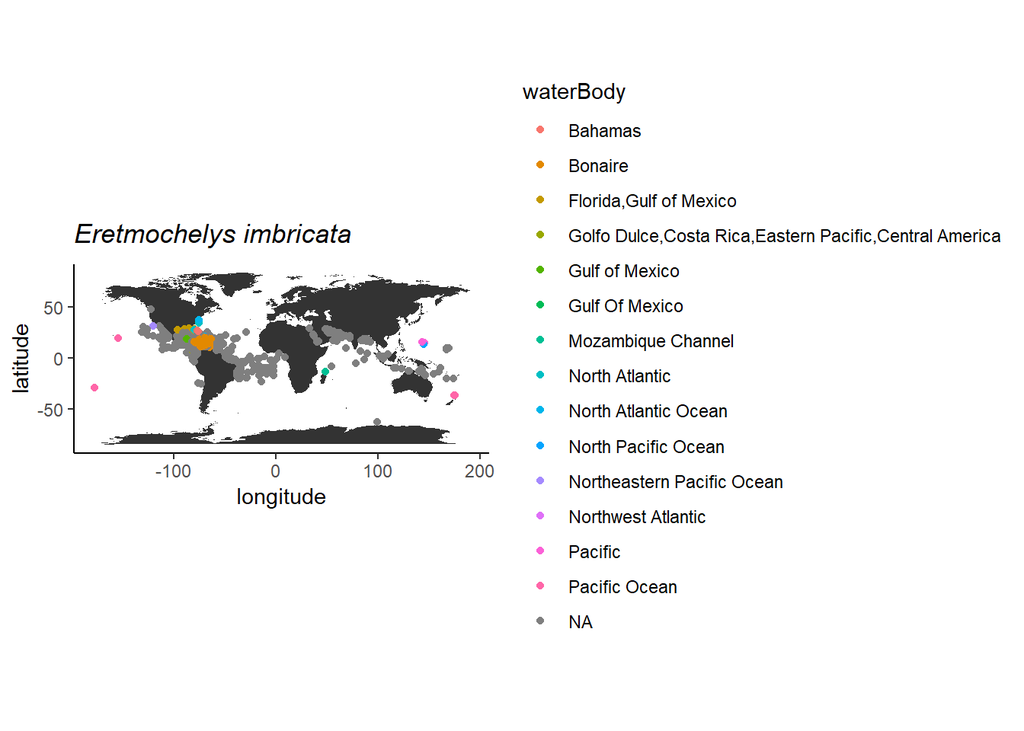

```r
ggplot() +
  geom_polygon(data = world, aes(x = long, y = lat, group = group)) +
  coord_fixed() +
  theme_classic() +
  geom_point(data = eret_obis_ok, aes(x = decimalLongitude, y = decimalLatitude, color = waterBody)) +
  labs(x = "longitude", y = "latitude", title = expression(italic("Eretmochelys imbricata")))
```

## Unir GBIF e OBIS

```r
all_data <- bind_rows(eret_gbif_ok %>%
                        mutate(repo = paste0("gbif", row.names(.))),
                      eret_obis_ok %>%
                        mutate(repo = paste0("obis", row.names(.)))) %>%
  column_to_rownames("repo") %>%
  dplyr::select(decimalLongitude, decimalLatitude, depth) %>%
  distinct() %>%
  rownames_to_column("occ") %>%
  separate(col = "occ", into = c("datasetName", "rn"), sep = 4) %>%
  mutate(scientificName = "Eretmochelys imbricata") %>%
  dplyr::select(-rn)
```

Mapa com todas as ocorrências

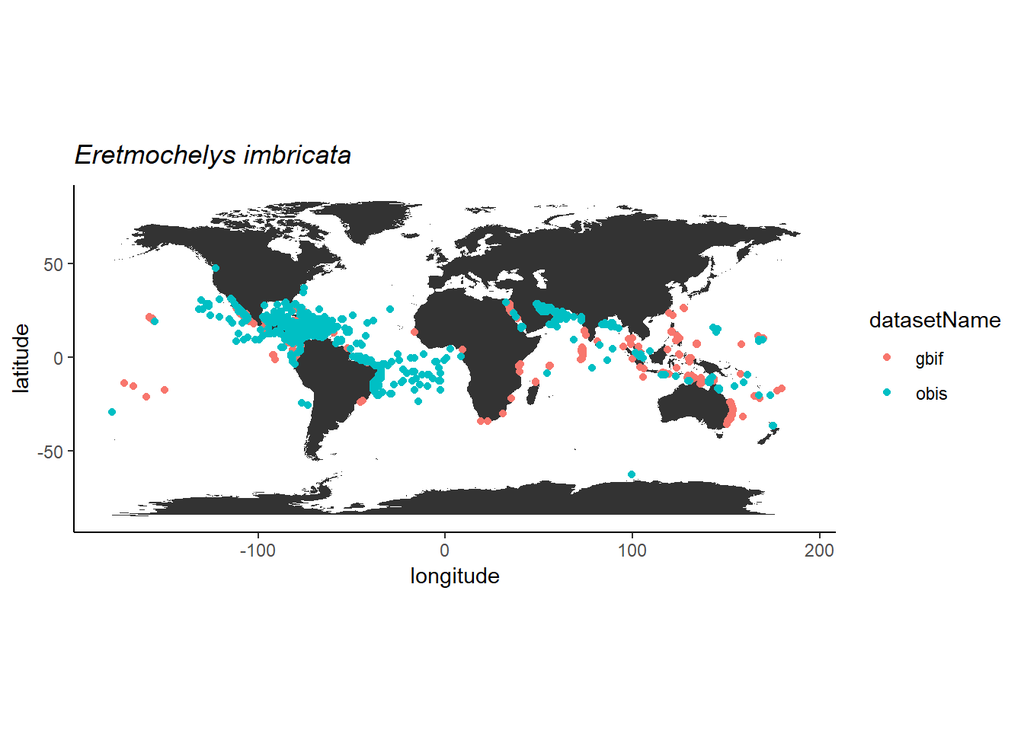

```r
ggplot() +
  geom_polygon(data = world, aes(x = long, y = lat, group = group)) +
  coord_fixed() +
  theme_classic() +
  geom_point(data = all_data, aes(x = decimalLongitude, y = decimalLatitude, color = datasetName)) +
  #theme(legend.title = element_blank()) +
  labs(x = "longitude", y = "latitude", title = expression(italic("Eretmochelys imbricata")))
```

```r
write.csv(all_data, "occ_GBIF-OBIS_par_hepa.csv", row.names = FALSE)
```

## Retirar ocorrências suspeitas

### Função

Função para retirar ocorrências suspeitas

```r
flag_outlier <- function(df, species){

  # funcao para classificar ocorrencias suspeitas
  # baseada no calculo do centroide de todas ocorrencias
  # indica como 'check' as ocorrencias que tem distancias at? o centroide
  # acima do 90th quantil (default) das distancias calculadas

  dados <- df %>%
    dplyr::filter(scientificName == species);

  dados2 <- geosphere::distVincentyEllipsoid(
    dados %>%
      summarise(centr_lon = median(decimalLongitude),
                centr_lat = median(decimalLatitude)),
    dados %>%
      dplyr::select(decimalLongitude, decimalLatitude)
  ) %>%
    bind_cols(dados) %>%
    rename(dist_centroid = '...1') %>%
    mutate(flag = ifelse(dist_centroid < quantile(dist_centroid, probs = 0.9), "OK",
                         ifelse(dist_centroid >= quantile(dist_centroid, probs = 0.90) & dist_centroid < quantile(dist_centroid, probs = 0.95), "check > Q90",
                                ifelse(dist_centroid >= quantile(dist_centroid, probs = 0.95), "check > Q95", "OK"))))

  # mutate(flag = ifelse(dist_centroid > quantile(dist_centroid, probs = prob), "check", "OK"))

  print(dados2)

}
```

Aplicar a função anterior nos dados

```r
marcados <- eret_gbif$data %>%
  data.frame() %>%
  dplyr::select(scientificName, decimalLongitude, decimalLatitude, datasetName) %>%
  distinct() %>%
  flag_outlier(., "Eretmochelys imbricata (Linnaeus, 1766)")
```

```
## * NA -> ...1
```

```
##     dist_centroid                          scientificName decimalLongitude
## 1     13910499.30 Eretmochelys imbricata (Linnaeus, 1766)      -156.409890
## 2     16831229.02 Eretmochelys imbricata (Linnaeus, 1766)      -106.583620
## 3      5333781.49 Eretmochelys imbricata (Linnaeus, 1766)       120.908755
## 4      5330218.25 Eretmochelys imbricata (Linnaeus, 1766)       120.885162
## 5     13137178.09 Eretmochelys imbricata (Linnaeus, 1766)       -45.402038
## 6      5340335.87 Eretmochelys imbricata (Linnaeus, 1766)       120.976164
## 7      8043354.27 Eretmochelys imbricata (Linnaeus, 1766)       143.500000
## 8      8024994.68 Eretmochelys imbricata (Linnaeus, 1766)       143.500000
## 9     10613923.94 Eretmochelys imbricata (Linnaeus, 1766)       166.763427
## 10     5333901.29 Eretmochelys imbricata (Linnaeus, 1766)       120.921879
## 11     9946637.15 Eretmochelys imbricata (Linnaeus, 1766)       159.046872
## 12     9264241.60 Eretmochelys imbricata (Linnaeus, 1766)       151.275561
## 13     7166552.09 Eretmochelys imbricata (Linnaeus, 1766)        18.927468
## 14     3894338.02 Eretmochelys imbricata (Linnaeus, 1766)        39.380762
```

[output cut: 1753 more lines]

Gerar o mapa

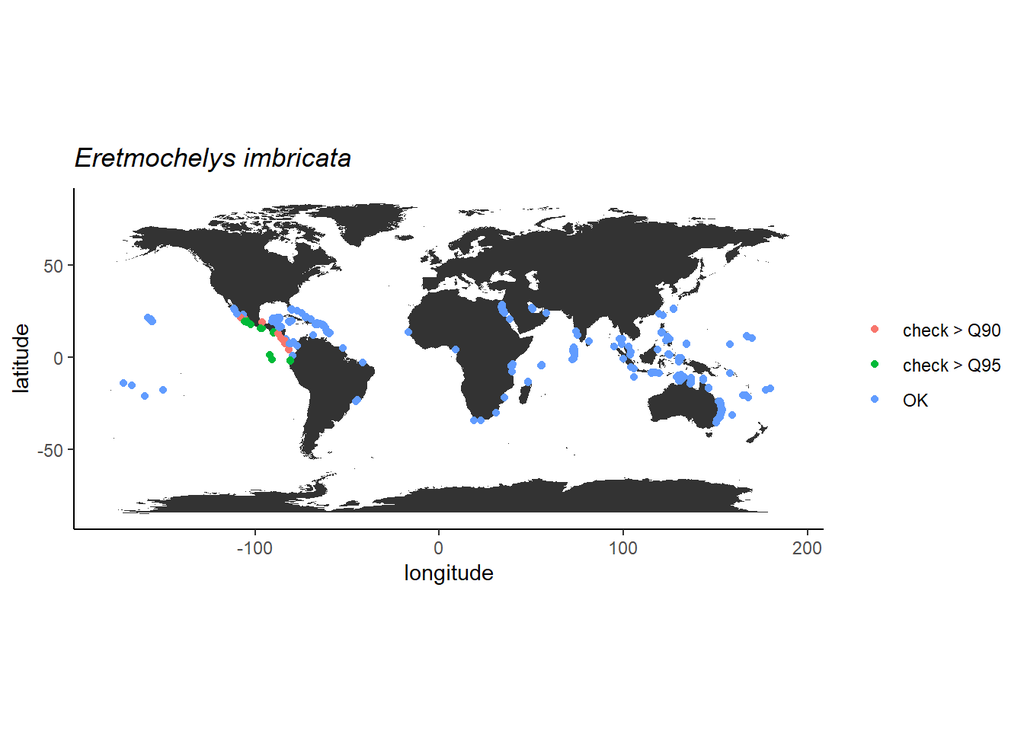

```r
ggplot() +
  geom_polygon(data = world, aes(x = long, y = lat, group = group)) +
  coord_fixed() +
  theme_classic() +
  geom_point(data = marcados,
             aes(x = decimalLongitude, y = decimalLatitude,
                 color = flag)) +
  theme(legend.title = element_blank()) +
  labs(x = "longitude", y = "latitude",
       title = expression(italic("Eretmochelys imbricata")))
```

### Pacote scrubr

Abrir o pacote necessário

```r
library(scrubr)
```

Usando o pacote

```r
data_scrubr <- marcados %>%
  dframe() %>%
  coord_impossible() %>%
  coord_incomplete() %>%
  coord_unlikely() %>%
  dedup()
```

```
## Assuming 'decimalLatitude' is latitude
```

```
## Assuming 'decimalLongitude' is longitude
```

Gerar o mapa

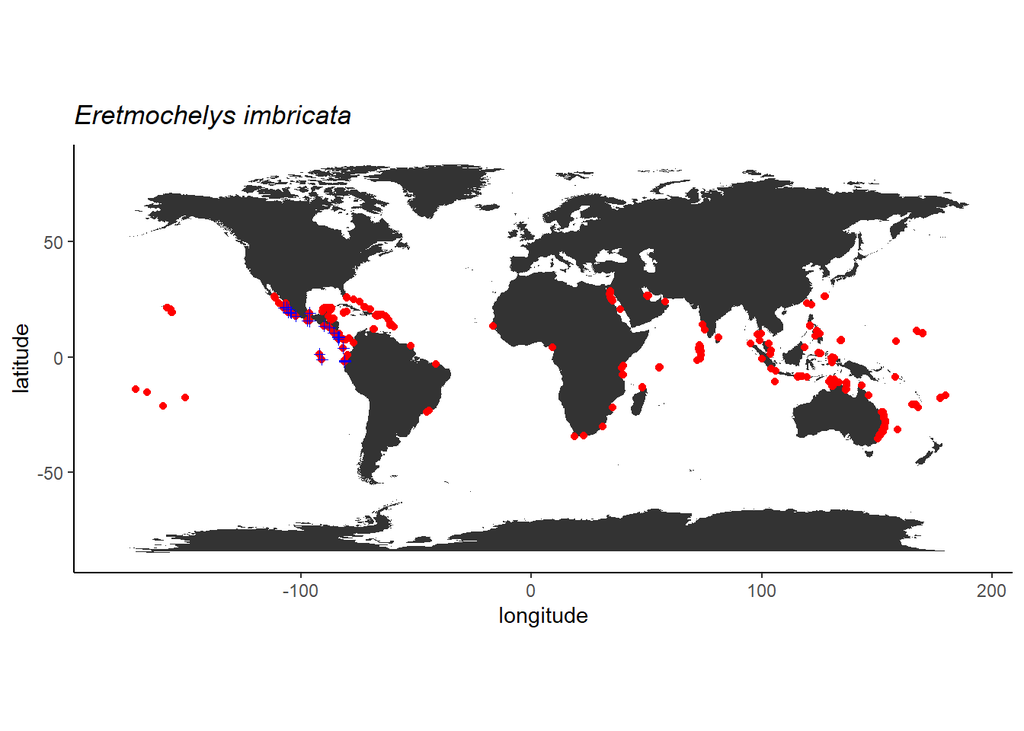

```r
ggplot() +
  geom_polygon(data = world, aes(x = long, y = lat, group = group)) +
  coord_fixed() +
  theme_classic() +
  geom_point(data = data_scrubr,
             aes(x = decimalLongitude, y = decimalLatitude),
             color = "red") +
  geom_point(data = marcados %>%
               filter(flag != "OK"),
             aes(x = decimalLongitude, y = decimalLatitude),
             color = "blue", shape = 3) +
  theme(legend.title = element_blank()) +
  labs(x = "longitude", y = "latitude",
       title = expression(italic("Eretmochelys imbricata")))
```

### Pacote obistools

Abrir o pacote necessário

```r
library(obistools)
```

Usando o pacote

```r
eret_obis %>%
  dplyr::select(decimalLongitude, decimalLatitude, scientificNameID) %>%
  distinct() %>%
  check_outliers_dataset(., report = FALSE, iqr_coef = 1, mad_coef = 5) %>%
  dim()
```

```
## [1] 3935    3
```

Gerar o mapa

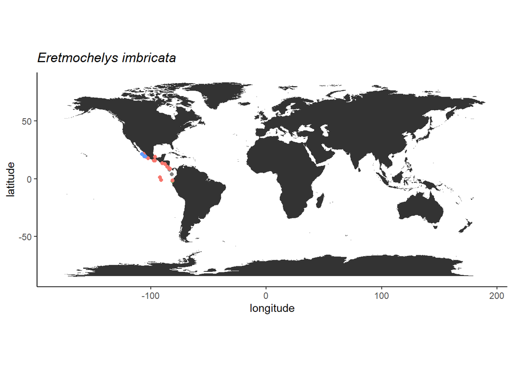

```r
ggplot() +
  geom_polygon(data = world, aes(x = long, y = lat, group = group)) +
  coord_fixed() +
  theme_classic() +
  geom_point(data = marcados %>%
               filter(flag != "OK"),
             aes(x = decimalLongitude, y = decimalLatitude,
                 color = datasetName)) +
  theme(legend.position="none") +
  labs(x = "longitude", y = "latitude",
       title = expression(italic("Eretmochelys imbricata")))
```

### Pacote CoordinateCleaner

Abrir o pacote necessário

```r
library(CoordinateCleaner)
```

Testar nos dados

```r
flags <-
  clean_coordinates(
    x = marcados,
    lon = "decimalLongitude",
    lat = "decimalLatitude",
    species = "scientificName",
    tests = c("equal", "gbif",
              "zeros", "seas")
  )
```

```
## Testing coordinate validity
```

```
## Flagged 0 records.
```

```
## Testing equal lat/lon
```

```
## Flagged 0 records.
```

```
## Testing zero coordinates
```

```
## Flagged 0 records.
```

```
## Testing sea coordinates
```

```
## Flagged 346 records.
```

```
## Testing GBIF headquarters, flagging records around Copenhagen
```

```
## Flagged 0 records.
```

```
## Flagged 346 of 441 records, EQ = 0.78.
```